# DeepInsight Visible Neural Network: Quick Start divnn R

Herdiantri Sufriyana, Yu-Wei Wu and Emily Chia-Yu Su

Graduate Institute of Biomedical Informatics, College of Medical Science and Technology, Taipei Medical University, Taipei, Taiwan  
Department of Medical Physiology, College of Medicine, University of Nahdlatul Ulama Surabaya, Surabaya, Indonesia  
Clinical Big Data Research Center, Taipei Medical University Hospital, Taipei, Taiwan  
Research Center for Artificial Intelligence in Medicine, Taipei Medical University, Taipei, Taiwan

herdiantrisufriyana@unusa.ac.id

4 March 2021

#### Abstract

This vignette explains how to use this package using simulated data. However, reader may need to read another vignette to apply the DeepInsight Visible Neural Network (DI-VNN) model based on the original works of DeepInsight and VNN from Alok Sharma [1] and Michael Ku Yu [2], respectively.

#### Package

divnn 0.1.3

# 1 Install and load

You can install this package using function install_github() from devtools package. Then load this package.

```r
devtools::install_github('herdiantrisufriyana/divnn')
library(divnn)
```

Several packages are needed to load explicitly since training and the other functions are not included in this package. For simplicity, code to turn off your GPU is also provided below.

```r
library(tidyverse)
library(BiocGenerics)
library(Biobase)
library(pbapply)
Sys.setenv('CUDA_VISIBLE_DEVICES'=-1)
library(keras)
use_backend('tensorflow')
library(igraph)
```

# 2 Load simulated data

Load simulated data using this code.

```r
input=utils.example()
```

The first input is an instance-feature value data frame with rows for instances and columns for features. All rows in value should have names. All values should be numerics.

Show only the first six rows.

Table 1: Instance-feature value data frame

|  | F1 | F2 | F3 | F4 | F5 |
| --- | --- | --- | --- | --- | --- |
| I1 | -0.1359245 | -0.0407970 | 1.0105390 | -0.1582624 | -2.1566375 |
| I2 | 0.4986468 | -0.7552443 | 0.7785852 | 0.7545780 | -1.0995456 |
| I3 | 0.1673500 | -0.0292835 | 1.8758450 | 0.2446345 | 0.7021537 |
| I4 | -0.0150857 | -0.1433701 | 0.3206666 | 0.1223341 | -0.5946652 |
| I5 | -0.4423948 | 0.2905036 | 0.7236534 | 0.4595739 | 0.1851052 |
| I6 | 0.2338050 | 0.5933383 | 2.0011669 | -1.8371978 | -0.8623909 |

Table above is summarized below.

Table 2: Summary of instance-feature value data frame

| attribute | outcome_0 | outcome_1 |
| --- | --- | --- |
| F1 | 0.3 ± 0.91 | -0.31 ± 0.97 |
| F2 | -0.57 ± 0.83 | 0.59 ± 0.79 |
| F3 | 0.26 ± 0.95 | -0.29 ± 0.99 |
| F4 | -0.3 ± 0.95 | 0.26 ± 0.98 |
| F5 | 0.35 ± 0.9 | -0.28 ± 0.94 |
| outcome | 1498 | 1502 |

The second input is and outcome vector of binary integers with the same length as the instances. The length and the order of outcome should be the same with those of value. Value of 0 and 1 should refer to non-event and event outcome, respectively.

```
##  I1  I2  I3  I4  I5  I6  I7  I8  I9 I10
##   1   0   0   1   1   0   0   0   0   1
```

The third input is a similarity matrix of numerics containing feature-feature similarity measures.

Table 3: Feature similarity matrix

|  | F1 | F2 | F3 | F4 | F5 |
| --- | --- | --- | --- | --- | --- |
| F1 | 1.0000000 | -0.0291670 | -0.0097115 | -0.0100418 | 0.0149212 |
| F2 | -0.0291670 | 1.0000000 | -0.0100969 | 0.0069537 | -0.0548541 |
| F3 | -0.0097115 | -0.0100969 | 1.0000000 | -0.0154304 | 0.0078851 |
| F4 | -0.0100418 | 0.0069537 | -0.0154304 | 1.0000000 | -0.0088595 |
| F5 | 0.0149212 | -0.0548541 | 0.0078851 | -0.0088595 | 1.0000000 |

The fourth input is a feature three-dimensional mapping matrix of numerics with rows for features and three columns for three dimensions where the features are mapped onto.

Table 4: Feature three-dimensional mapping matrix

|  | dimension 1 | dimension 2 | dimension 3 |
| --- | --- | --- | --- |
| F1 | -0.3445922 | 0.3823556 | -0.6741419 |
| F2 | 0.6883690 | -0.1021583 | -0.2998355 |
| F3 | -0.0936063 | -0.7789270 | 0.0801490 |
| F4 | 0.2840867 | 0.4861979 | 0.5848708 |
| F5 | -0.5638589 | 0.0158824 | 0.3273127 |

The fifth input is an ontology data frame with rows for ontologies and four columns for source, target, similarity, and relation. Feature (source)- ontology (target) relation should be annotated as ‘feature’, while ontology- ontology relation should be annotated as ‘is_a’. To differentiate between feature and ontology names, a prefix of ‘ONT:’ precedes an ontology name. All columns except similarity in ontology should be characters. Similarity (a numeric) is a minimum threshold by which either features or ontologies (source) belong to an ontology (target).

Table 5: Ontology data frame

| source | target | similarity | relation |
| --- | --- | --- | --- |
| F1 | ONT:1 | 0.5074606 | feature |
| F5 | ONT:1 | 0.5074606 | feature |
| F2 | ONT:2 | 0.5034769 | feature |
| F4 | ONT:2 | 0.5034769 | feature |
| F3 | ONT:3 | 0.4951443 | feature |
| ONT:1 | ONT:3 | 0.4951443 | is_a |
| ONT:2 | ONT:4 | 0.4725730 | is_a |
| ONT:3 | ONT:4 | 0.4725730 | is_a |

In addition, a result of hierarchical clustering is also shown below for visualization to get intuition how the features are grouped and how the connection constructs the VNN model architecture.

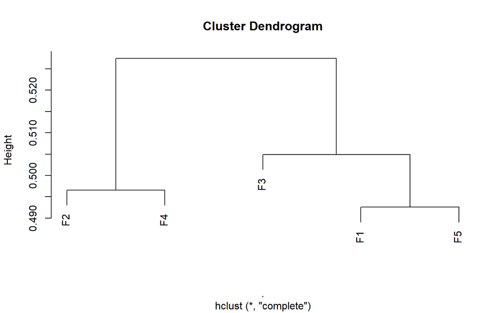

Figure 1: Ontology by hierarchical clustering

# 3 Compile to a TidySet

Compile input to a TidySet using this code.

```r
tidy_set=
  TidySet.compile(
    value=input$value
    ,outcome=input$outcome
    ,similarity=input$similarity
    ,mapping=input$mapping
    ,ontology=input$ontology
  )
```

TidySet is an ExpressionSet with three tables. Instance-feature value data frame and outcome vector are compiled as a phenotype data frame with rows for instances and columns for features and outcome.

```
## ExpressionSet (storageMode: lockedEnvironment)
## assayData: 49 features, 3000 samples
##   element names: exprs
## protocolData: none
## phenoData
##   sampleNames: I1 I2 ... I3000 (3000 total)
##   varLabels: outcome F2 ... F1 (6 total)
##   varMetadata: labelDescription
## featureData
##   featureNames: x1y1z1 x2y1z1 ... x7y7z1 (49 total)
##   fvarLabels: feature ONT1 ... ONT4 (5 total)
##   fvarMetadata: labelDescription
## experimentData: use 'experimentData(object)'
## Annotation:
```

Instance-feature value data frame and feature three-dimensional mapping matrix are compiled as an expression matrix with rows for positions of features and columns for instances. The mapping and similarity matrices and ontology data frame are compile as a feature data frame with rows for positions of features and columns for feature names and ontological relations. For easier access, the original ontology data frame is included in experiment information at section ‘notes’ as a list.

Table 6: Dimensions of three tables

|  | dimension 1 | dimension 2 |
| --- | --- | --- |
| Phenotype data frame | 3000 | 6 |
| Feature data frame | 49 | 5 |
| Expression matrix | 49 | 3000 |

Recall experiment notes such similarity, ontomap, ontotype, and ontology using this code.

```r
# Recall a similarity matrix
notes(tidy_set)$similarity

# Recall an ontomap four-dimensional array
notes(tidy_set)$ontomap

# Recall an ontotype list of two-dimensional matrices
notes(tidy_set)$ontotype

# Recall an ontology data frame
notes(tidy_set)$ontology
```

# 4 Save or load a TidySet

Use this code to save a TidySet by writing a .ts.tar.gz file containing exprs.csv, pData.csv, fData.csv, similarity.csv, ontology.csv, and others.txt.

```r
TidySet.write(tidy_set,'quick-start-R/tidy_set_R')
```

Function of TidySet.read can read this file back to a TidySet. Use this code to load a TidySet by reading a .ts.tar.gz file.

```r
tidy_set=TidySet.read('quick-start-R/tidy_set_R.ts.tar.gz')
```

# 5 Create ontonet

Let’s create a function that generate a Keras Convolutional Neural Network (CNN) model with a specific layer architecture for each path in the hierarchy of the given ontology. The model architecture can be saved to JSON for later use by specifying the file path; otherwise (by let it NULL), no JSON will be created.

```r
ontonet=
  tidy_set %>%
  generator.ontonet(path='quick-start-R/ontonet_R')
```

# 6 Tuning parameters

The model is compiled with stochastic gradient decent (SGD) using learning rate (LR) of 2^-6, momentum of 0.9, and decay 10^-4. The loss function is mean squared error (MSE) with weight of 1 for main output and 0.3 fir auxiliary output. The evaluation metric is accuracy.

The LR will be reduced by factor of 0.1 at iteration 30, 60, and 80. Early stopping will also happen if validation loss does not decrease >0.001 after 30 iterations. The best weight at minimum validation loss will be applied.

```r
ontonet %>%
  compile(
    optimizer=optimizer_sgd(lr=2^-6,momentum=0.9,decay=10^-4)
    ,loss='mean_squared_error'
    ,loss_weights=c(rep(0.3,length(.$outputs)-1),1)
    ,metrics='accuracy'
  )

cb_lr_reduction=
  callback_learning_rate_scheduler(
    function(epoch,lr){
      lr_factor=0.1
      if(epoch %in% c(30,60,80)) lr=lr*lr_factor
      lr
    }
  )

cb_early_stopping=
  callback_early_stopping(
    monitor='val_loss'
    ,mode='min'
    ,min_delta=0.001
    ,patience=30
    ,restore_best_weights=T
  )
```

# 7 Data partition

We hold out ~20% dataset for test set, while ~20% of the remaining will be a validation set. Training set will use the 80% of the remaining instances.

Table 7: Data partition

| set | outcome_0 | outcome_1 |
| --- | --- | --- |
| train | 965 | 955 |
| validation | 229 | 251 |
| test | 304 | 296 |

# 8 Model training

We use this code to train the model. The sample generator for ontoarray will take 32 samples for each batch. This step is repeated until all samples of training set are used per epoch, up to 100 epochs, but can be stopped earlier. For each epoch, validation performance is also measured with the same batch size.

```r
history=
  ontonet %>%
  fit_generator(
    generator=
      generator.ontoarray(
        tidy_set
        ,index[train_i]
        ,batch_size=32
      )
    ,steps_per_epoch=ceiling(length(train_i)/32)
    ,validation_data=
      generator.ontoarray(
        tidy_set
        ,index[val_i]
        ,batch_size=32
      )
    ,validation_steps=ceiling(length(val_i)/32)
    ,epochs=100
    ,callbacks=c(cb_lr_reduction,cb_early_stopping)
    ,view_metrics=F
    ,verbose=1
  )
```

Here below is the training result. We can estimate the iteration of which the weights are optimum for prediction.

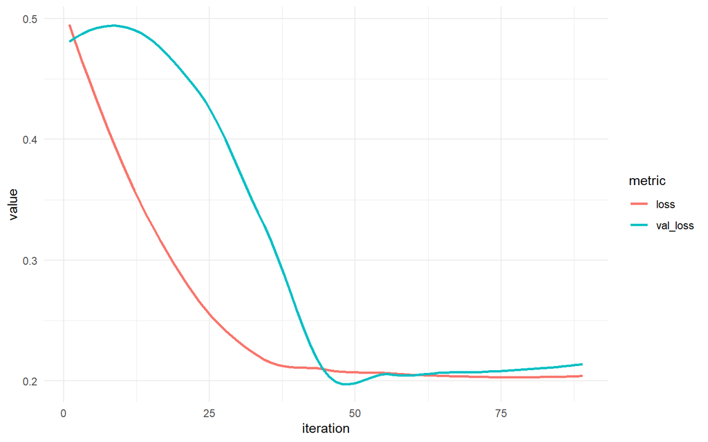

Figure 2: Plot training and validation losses

# 9 Model evaluation

```r
set.seed(33)
evaluation=
  pblapply(X=1:30,function(X){
    test_i=sample(test_i,length(test_i),T)
    ontonet %>%
      evaluate_generator(
        generator=
          generator.ontoarray(
            tidy_set
            ,index[test_i]
            ,batch_size=32
          )
        ,steps=ceiling(length(test_i)/32)
      )
  })
```

The point and interval (95% CI) estimates of accuracy can be computed by the bootstrapping.

Table 8: Accuracy estimates (95% CI) on test set

| metric | mean | lb | ub |
| --- | --- | --- | --- |
| root_accuracy | 0.950329 | 0.9476059 | 0.953052 |

# 10 Model exploration

We can visualize both ontonet and ontoarray. Each visualization uses a function to prepare the visualization tables. Using these tables, we can explore the model using plot() function.

```r
visualization=list()

visualization$ontonet=
  tidy_set %>%
  viz.ontonet(
    feature=T
    ,eval.results=evaluation
    ,eval.metric='accuracy'
    ,eval.pal=c('#E64B35FF','#00A087FF')
  )

visualization$ontoarray=
  tidy_set %>%
  viz.ontoarray(ontonet,batch_size=32,verbose=F)

visualization
```

```
## $ontonet
##
##     Method: viz.ontonet
##
##     Ontonet node and edge tables for visualization purpose
##
##     Total:
##       10 nodes
##       9 edges
##
## $ontoarray
##
##     Method: viz.ontoarray
##
##     A representation layer per ontology as relative values between event and
##     non-event for visualization purpose.
##
##     Total: 5 ontologies
##
```

We can the accuracy is improved along with the higher ontology. At the top one, the accuracy is 93%. Root ontology have a slightly higher accuracy; yet, the features are sufficient to achieve a satisfying predictive performance. The F2 and F4 likely contributes the most. However, we do not know yet whether these features prefer event or non-event.

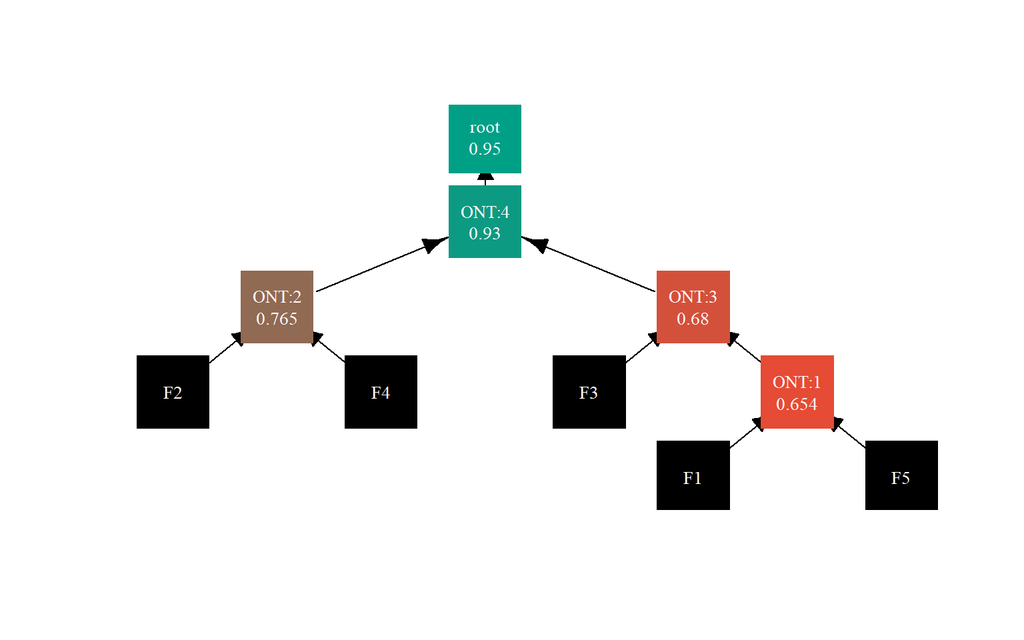

Figure 3: Ontonet showing accuracy per ontology

```r
visualization$ontonet %>%
  plot(
    node.shape='square'
    ,label=T
    ,label.family='serif'
    ,label.cex=0.85
    ,asp=0
    ,ylim=c(-1,1)
    ,xlim=c(-1,1)
  )
```

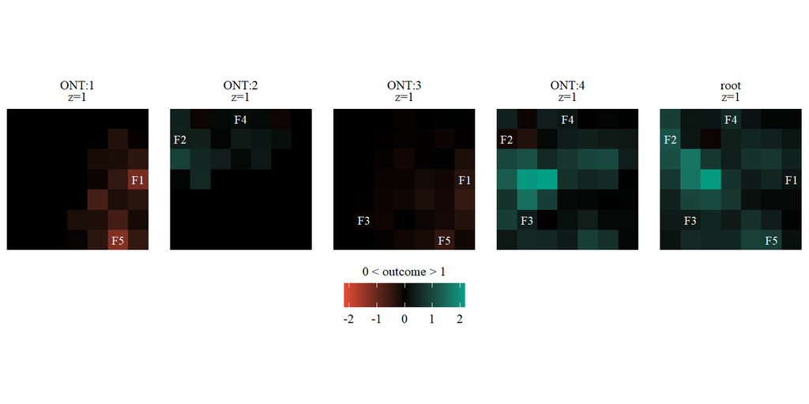

Figure 4: Ontoarray representation

```r
visualization$ontoarray %>%
  plot(
    pal=c('#E64B35FF','#00A087FF')
    ,label=T
    ,label.family='serif'
    ,label.size=3
    ,grid_col=5
  )
```

# 11 Conclusion

In conclusion, DI-VNN demonstrates a satisfying predictive performance for this simulated dataset. More studies and dataset are still needed to test the generalizability of this model. Anyway, this model is intended to improve explorability of machine learning. By DI-VNN, we can explore interaction among features in the context of predicting the outcome, not merely ranking the variable importance.

# 12 References

[1] Sharma A, Vans E, Shigemizu D, Boroevich KA, Tsunoda T, DeepInsight: a methodology to transform a non-image data to an image for convolution neural network architecture, Scientific Reports, 9:11399, pp. 1-7, 2019. [Paper.pdf](http://www.alok-ai-lab.com/materials/DeepInsight.pdf) [Supplement .pdf](http://www.alok-ai-lab.com/materials/DeepInsight_Supp.pdf) [DeepInsight Matlab Code: Tested on Ubuntu 18.10.](http://www.alok-ai-lab.com/materials/DeepInsight_Pkg.tar.gz)

[2] Ma, J., Yu, M., Fong, S. et al. Using deep learning to model the hierarchical structure and function of a cell. Nat Methods 15, 290–298 (2018). [Paper](https://doi.org/10.1038/nmeth.4627) [Author GitHub](https://github.com/michaelkyu/) [DCell code](https://github.com/idekerlab/DCell/)